# Analytical Sales Report

Practicum II CS5200

Sai Prasasth Koundinya Gandrakota

Spring 2024

## Top 5 Sales Reps with the Most Sales (Broken Down by Year)

Below are the tables for the top five sales reps in each year, ordered by most amount sold to least amount sold:

Top 5 Sales Reps with Most Sales in 2020

| repName | totalAmountSold |
| --- | --- |
| Walison da Silva | $ 4,187,637 |
| Aneeta Kappoorthy | $ 2,894,565 |
| Lynette McRowe | $ 2,662,449 |
| Prasad Patel | $ 2,072,111 |
| Helmut Schwab | $ 1,772,660 |

NA

Top 5 Sales Reps with Most Sales in 2021

| repName | totalAmountSold |
| --- | --- |
| Walison da Silva | $ 8,827,810 |
| Lynette McRowe | $ 6,405,098 |
| Aneeta Kappoorthy | $ 6,128,682 |
| Prasad Patel | $ 3,723,865 |
| Helmut Schwab | $ 3,020,853 |

NA

Top 5 Sales Reps with Most Sales in 2022

| repName | totalAmountSold |
| --- | --- |
| Walison da Silva | $ 4,792,071 |
| Aneeta Kappoorthy | $ 2,862,217 |
| Lynette McRowe | $ 2,391,484 |
| Prasad Patel | $ 2,243,208 |
| Helmut Schwab | $ 1,596,928 |

NA

From the above tables it is observed that Walison da Silva had the highest sales record in all years and it can also be noted that the top 5 sales amounts in 2021 is higher than the other years.

## Total Sold per Product per Quarter

Below is the table for the total amount sold in each quarter across all years for every product, ordered by product names alphabetically:

Amount Sold per Product per Quarter

| Product | Q1 | Q2 | Q3 | Q4 |
| --- | --- | --- | --- | --- |
| Alaraphosol | $ 328,808 | $ 421,452 | $ 382,812 | $ 318,228 |
| Bhiktarvizem | $ 1,391,652 | $ 1,780,974 | $ 1,867,275 | $ 1,346,760 |
| Clobromizen | $ 522,720 | $ 681,120 | $ 735,840 | $ 526,896 |
| Colophrazen | $ 445,752 | $ 604,791 | $ 565,062 | $ 488,433 |
| Diaprogenix | $ 15,524 | $ 17,068 | $ 18,120 | $ 17,448 |
| Gerantrazeophem | $ 718,828 | $ 997,832 | $ 895,730 | $ 701,250 |
| Presterone | $ 355,200 | $ 485,500 | $ 424,800 | $ 366,700 |
| Proxinostat | $ 952,210 | $ 989,228 | $ 1,080,435 | $ 928,572 |
| Xinoprozen | $ 1,036,350 | $ 1,154,226 | $ 1,329,630 | $ 1,089,648 |
| Xipramin | $ 144,792 | $ 163,800 | $ 175,248 | $ 130,968 |
| Zalofen | $ 7,398,300 | $ 8,829,600 | $ 9,293,700 | $ 7,534,800 |

From the table above we can observe that sales are usually higher in Q2 and Q3 for almost all the products compared to Q1 and Q4. We can also observe that sales amount for certain products like Zalofen are way higher than products like Diaprogenix across all quarters, due to difference in cost per unit.

## Number of Units Sold per Product per Region

Below is the table and line graph representing the number of units sold for each product in each region, ordered and grouped by product name:

Units Sold per Product per Region (First 12 rows)

| prodName | territory | numUnitSold |
| --- | --- | --- |
| Alaraphosol | East | 296,500 |
| Alaraphosol | EMEA | 510,600 |
| Alaraphosol | South America | 475,500 |
| Alaraphosol | West | 294,900 |
| Bhiktarvizem | East | 351,600 |
| Bhiktarvizem | EMEA | 467,100 |
| Bhiktarvizem | South America | 480,300 |
| Bhiktarvizem | West | 351,300 |
| Clobromizen | East | 355,300 |
| Clobromizen | EMEA | 478,600 |
| Clobromizen | South America | 486,600 |
| Clobromizen | West | 392,400 |

From the table above we can see the exact values of total number of units sold in each region for each product.

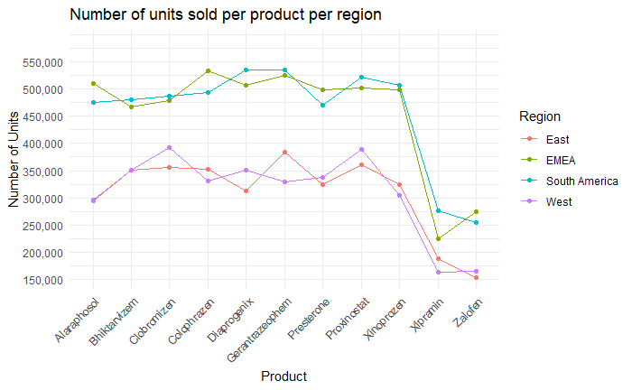

From the graph above we can see the comparison between units sold in each region for each product. A higher quantity of units have been sold in the EMEA and South America regions compared to the East and West regions for all products.

## Average Sales per Sales Rep (Over The Years)

Below is the table and line graph depicting the average sale amount and the total number of sales for each rep in each year, ordered by year and the average sale amount.

Average Sales per Sales Rep per Year

| repName | year | totalNumSales | avgAmountSold |
| --- | --- | --- | --- |
| Helmut Schwab | 2020 | 408 | $ 4,344.8 |
| Veronika Sixt | 2020 | 257 | $ 3,925.7 |
| Prasad Patel | 2020 | 563 | $ 3,680.5 |
| Walison da Silva | 2020 | 1184 | $ 3,536.9 |
| Aneeta Kappoorthy | 2020 | 826 | $ 3,504.3 |
| Lynette McRowe | 2020 | 825 | $ 3,227.2 |
| Helmut Schwab | 2021 | 757 | $ 3,990.6 |
| Lynette McRowe | 2021 | 1657 | $ 3,865.5 |
| Aneeta Kappoorthy | 2021 | 1669 | $ 3,672.1 |
| Walison da Silva | 2021 | 2421 | $ 3,646.3 |
| Prasad Patel | 2021 | 1026 | $ 3,629.5 |
| Veronika Sixt | 2021 | 524 | $ 3,057.0 |
| Veronika Sixt | 2022 | 260 | $ 5,621.8 |
| Prasad Patel | 2022 | 548 | $ 4,093.4 |
| Walison da Silva | 2022 | 1195 | $ 4,010.1 |
| Helmut Schwab | 2022 | 412 | $ 3,876.0 |
| Aneeta Kappoorthy | 2022 | 750 | $ 3,816.3 |
| Lynette McRowe | 2022 | 748 | $ 3,197.2 |

From the table above we can see that Helmut Schwab had a higher average sale amount in 2020 and 2021 while having a less number of sales during that period. Similarly we can see that the number of sales was higher in 2021 for all sales reps.

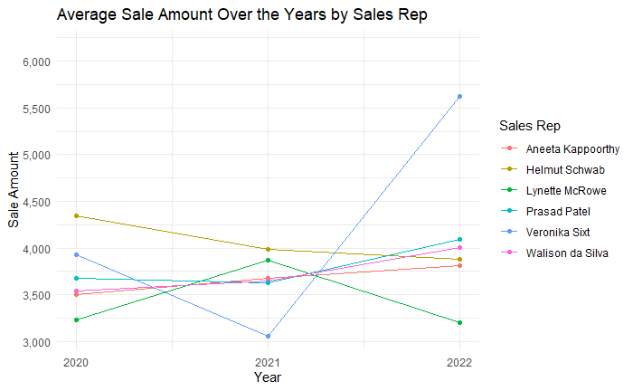